# Complex_Diet Data Analysis

#### Volcano plot for interaction terms:

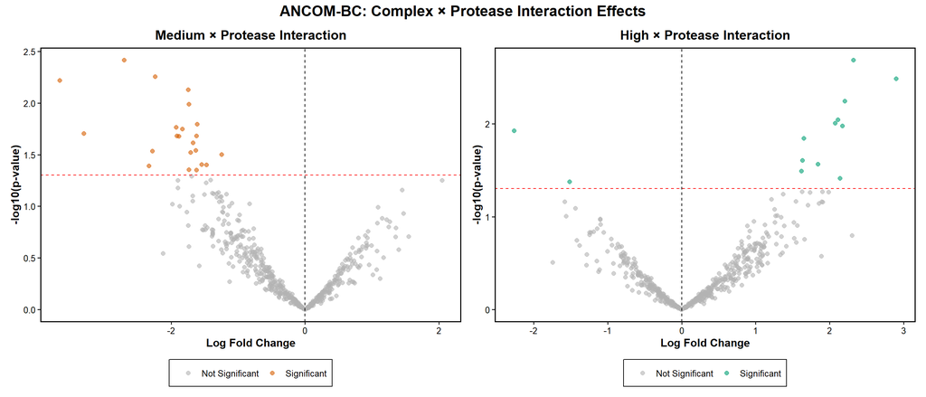

```r
# Medium:Protease interaction
ancom_interaction_res$sig_med_int <- ifelse(
  ancom_interaction_res$`p_complexmedium:proteaseprot` < 0.05,
  "Significant", "Not Significant"
)

p1 <- ggplot(ancom_interaction_res,
             aes(x = `lfc_complexmedium:proteaseprot`,
                 y = -log10(`p_complexmedium:proteaseprot`),
                 color = sig_med_int)) +
  geom_point(alpha = 0.6, size = 2) +
  scale_color_manual(values = c("Significant" = "#D55E00", "Not Significant" = "grey70")) +
  geom_hline(yintercept = -log10(0.05), linetype = "dashed", color = "red") +
  geom_vline(xintercept = 0, linetype = "dashed", color = "black") +
  labs(
    x = "Log Fold Change",
    y = "-log10(p-value)",
    color = "",
    title = "Medium × Protease Interaction"
  ) +
  theme_publication +
  theme(legend.position = "bottom")

# High:Protease interaction
ancom_interaction_res$sig_high_int <- ifelse(
  ancom_interaction_res$`p_complexhigh:proteaseprot` < 0.05,
  "Significant", "Not Significant"
)

p2 <- ggplot(ancom_interaction_res,
             aes(x = `lfc_complexhigh:proteaseprot`,
                 y = -log10(`p_complexhigh:proteaseprot`),
                 color = sig_high_int)) +
  geom_point(alpha = 0.6, size = 2) +
  scale_color_manual(values = c("Significant" = "#009E73", "Not Significant" = "grey70")) +
  geom_hline(yintercept = -log10(0.05), linetype = "dashed", color = "red") +
  geom_vline(xintercept = 0, linetype = "dashed", color = "black") +
  labs(
    x = "Log Fold Change",
    y = "-log10(p-value)",
    color = "",
    title = "High × Protease Interaction"
  ) +
  theme_publication +
  theme(legend.position = "bottom")

p1 + p2 +
  plot_annotation(title = "ANCOM-BC: Complex × Protease Interaction Effects",
                  theme = theme(plot.title = element_text(hjust = 0.5, face = "bold", size = 16)))
```

#### Heatmap of significant interaction taxa:

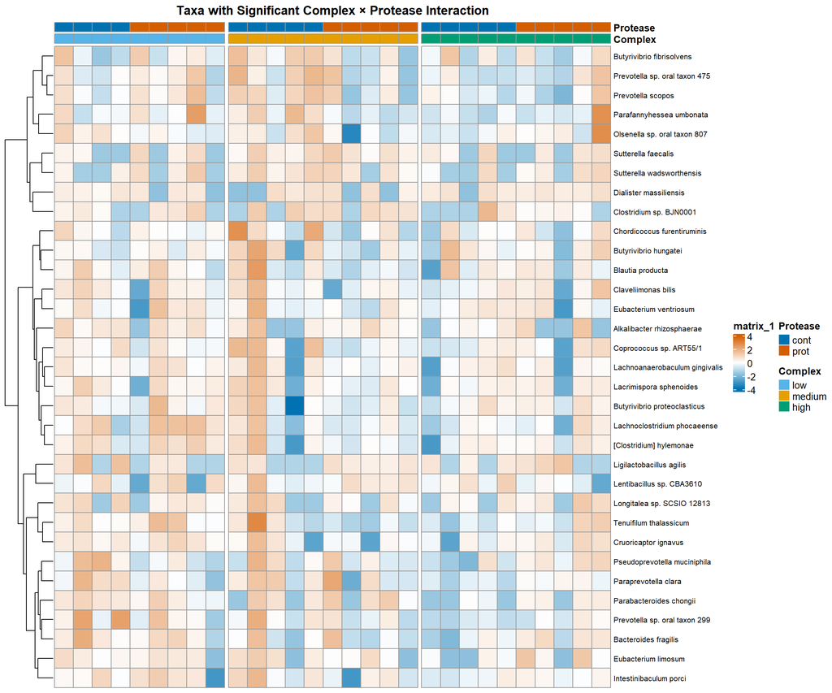

```r
# Get taxa with significant interactions
interaction_taxa <- ancom_interaction_res %>%
  filter(`p_complexmedium:proteaseprot` < 0.05 | `p_complexhigh:proteaseprot` < 0.05) %>%
  pull(taxon)

if (length(interaction_taxa) > 0) {

  # Get CLR-transformed abundances
  species_pseudo <- species_counts_filtered[interaction_taxa, , drop = FALSE] + 1
  species_clr <- log(species_pseudo) - rowMeans(log(species_pseudo))

  # Order samples by Complex (and then by Protease within Complex)
  sample_order <- rownames(meta_tab)[order(meta_tab$complex, meta_tab$protease)]

  # Reorder the CLR matrix columns
  species_clr_ordered <- species_clr[, sample_order]

  # Create annotation with ordered samples
  annotation_col <- data.frame(
    Complex = meta_tab[sample_order, "complex"],
    Protease = meta_tab[sample_order, "protease"],
    row.names = sample_order
  )

  annotation_colors <- list(
    Complex = complex_colors,
    Protease = protease_colors
  )

  # Add gaps between Complex groups
  # Find positions where Complex changes
  complex_ordered <- meta_tab[sample_order, "complex"]
  gaps_col <- which(complex_ordered[-1] != complex_ordered[-length(complex_ordered)])

  # Plot heatmap
  pheatmap(
    species_clr_ordered,
    scale = "row",
    cluster_rows = TRUE,
    cluster_cols = FALSE,
    clustering_distance_rows = "euclidean",
    clustering_method = "ward.D2",
    annotation_col = annotation_col,
    annotation_colors = annotation_colors,
    show_colnames = FALSE,
    gaps_col = gaps_col,
    color = colorRampPalette(c("#0072B2", "white", "#D55E00"))(100),
    fontsize_row = 8,
    fontsize_col = 8,
    main = "Taxa with Significant Complex × Protease Interaction"
  )
} else {
  print("No taxa with significant interaction effects")
}
```

#### **ANCOM-BC Volcano Plot - Protease:**

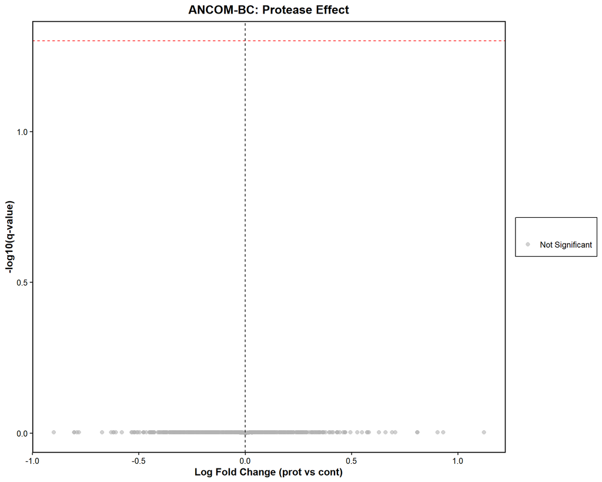

```r
# Prepare data
ancom_protease_res$significant <- ifelse(ancom_protease_res$diff_proteaseprot == TRUE,
                                          "Significant", "Not Significant")
ancom_protease_res$direction <- ifelse(ancom_protease_res$lfc_proteaseprot > 0,
                                        "Higher in prot", "Higher in cont")

# Volcano plot
p_volcano <- ggplot(ancom_protease_res, aes(x = lfc_proteaseprot, y = -log10(q_proteaseprot),
                                             color = significant)) +
  geom_point(alpha = 0.6, size = 2) +
  scale_color_manual(values = c("Significant" = "#D55E00", "Not Significant" = "grey70")) +
  geom_hline(yintercept = -log10(0.05), linetype = "dashed", color = "red") +
  geom_vline(xintercept = 0, linetype = "dashed", color = "black") +
  labs(
    x = "Log Fold Change (prot vs cont)",
    y = "-log10(q-value)",
    color = "",
    title = "ANCOM-BC: Protease Effect"
  ) +
  theme_publication

# Add labels for top significant taxa
if (nrow(ancom_protease_sig) > 0) {
  top_taxa <- head(ancom_protease_sig, 10)
  p_volcano <- p_volcano +
    geom_text_repel(data = ancom_protease_res[ancom_protease_res$taxon %in% top_taxa$taxon, ],
                    aes(label = taxon),
                    size = 3, max.overlaps = 15,
                    box.padding = 0.5)
}

p_volcano
```

#### ANCOM-BC Volcano Plot-Complex

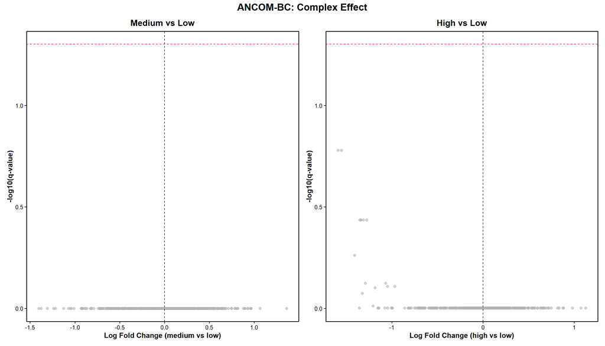

```r
# Medium vs Low
ancom_complex_res$sig_medium <- ifelse(ancom_complex_res$q_complexmedium < 0.05,
                                        "Significant", "Not Significant")

p1 <- ggplot(ancom_complex_res, aes(x = lfc_complexmedium, y = -log10(q_complexmedium),
                                     color = sig_medium)) +
  geom_point(alpha = 0.6, size = 2) +
  scale_color_manual(values = c("Significant" = "#E69F00", "Not Significant" = "grey70")) +
  geom_hline(yintercept = -log10(0.05), linetype = "dashed", color = "red") +
  geom_vline(xintercept = 0, linetype = "dashed", color = "black") +
  labs(
    x = "Log Fold Change (medium vs low)",
    y = "-log10(q-value)",
    color = "",
    title = "Medium vs Low"
  ) +
  theme_publication +
  theme(legend.position = "none")

# High vs Low
ancom_complex_res$sig_high <- ifelse(ancom_complex_res$q_complexhigh < 0.05,
                                      "Significant", "Not Significant")

p2 <- ggplot(ancom_complex_res, aes(x = lfc_complexhigh, y = -log10(q_complexhigh),
                                     color = sig_high)) +
  geom_point(alpha = 0.6, size = 2) +
  scale_color_manual(values = c("Significant" = "#009E73", "Not Significant" = "grey70")) +
  geom_hline(yintercept = -log10(0.05), linetype = "dashed", color = "red") +
  geom_vline(xintercept = 0, linetype = "dashed", color = "black") +
  labs(
    x = "Log Fold Change (high vs low)",
    y = "-log10(q-value)",
    color = "",
    title = "High vs Low"
  ) +
  theme_publication +
  theme(legend.position = "none")

p1 + p2 +
  plot_annotation(title = "ANCOM-BC: Complex Effect",
                  theme = theme(plot.title = element_text(hjust = 0.5, face = "bold", size = 16)))
```

### Consensus Approach (ALDEX2 + ANCOM-BC)

Aqui os taxas que tiveram p value menor que 0.05 nos dois metodos.

```r
# Find taxa significant in BOTH methods for Protease
aldex_sig_taxa <- aldex_protease_all$taxon[aldex_protease_all$wi.ep < 0.05]
ancom_sig_taxa <- ancom_protease_res$taxon[ancom_protease_res$p_proteaseprot < 0.05]

consensus_protease <- intersect(aldex_sig_taxa, ancom_sig_taxa)

# Create consensus table
if (length(consensus_protease) > 0) {
  consensus_protease_df <- data.frame(
    taxon = consensus_protease,
    aldex_effect = aldex_protease_all$effect[match(consensus_protease, aldex_protease_all$taxon)],
    aldex_pval = aldex_protease_all$wi.ep[match(consensus_protease, aldex_protease_all$taxon)],
    ancom_lfc = ancom_protease_res$lfc_proteaseprot[match(consensus_protease, ancom_protease_res$taxon)],
    ancom_pval = ancom_protease_res$p_proteaseprot[match(consensus_protease, ancom_protease_res$taxon)]
  )

  consensus_protease_df$direction <- ifelse(consensus_protease_df$aldex_effect > 0,
                                             "Higher in prot", "Higher in cont")

  consensus_protease_df <- consensus_protease_df[order(abs(consensus_protease_df$aldex_effect),
                                                        decreasing = TRUE), ]

  kable(consensus_protease_df, digits = 4,
        caption = paste0("Consensus: Taxa significant in both ALDEx2 and ANCOM-BC for Protease (n = ",
                         length(consensus_protease), ")"))
} else {
  print("No taxa significant in both methods for Protease")
}
```

Consensus: Taxa significant in both ALDEx2 and ANCOM-BC for Protease (n = 1)

| taxon | aldex_effect | aldex_pval | ancom_lfc | ancom_pval | direction |
| --- | --- | --- | --- | --- | --- |
| Salmonella enterica | 0.4534 | 0.0212 | 1.1229 | 0.0182 | Higher in prot |

#### Consensus Venn Diagram:

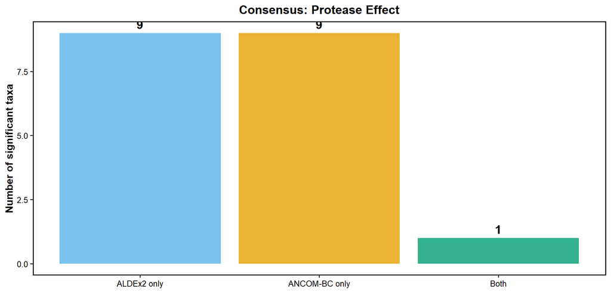

```r
# Create data for Venn-like visualization
venn_data <- data.frame(
  Method = c("ALDEx2 only", "ANCOM-BC only", "Both"),
  Count = c(
    length(setdiff(aldex_sig_taxa, ancom_sig_taxa)),
    length(setdiff(ancom_sig_taxa, aldex_sig_taxa)),
    length(consensus_protease)
  )
)

p_venn <- ggplot(venn_data, aes(x = Method, y = Count, fill = Method)) +
  geom_bar(stat = "identity", alpha = 0.8) +
  geom_text(aes(label = Count), vjust = -0.5, size = 5, fontface = "bold") +
  scale_fill_manual(values = c("ALDEx2 only" = "#56B4E9",
                                "ANCOM-BC only" = "#E69F00",
                                "Both" = "#009E73")) +
  labs(
    x = "",
    y = "Number of significant taxa",
    title = "Consensus: Protease Effect"
  ) +
  theme_publication +
  theme(legend.position = "none")

p_venn
```

### Plot selected taxa boxplots:

Bruno, aqui caso vc queira fazer alguns plots so de alguns taxas. Que vc achar interessante. Ai so mudar o nome e pedir para rodar. Esse codigo é para os fatores separadamento. Para vc descobrir o nome do taxa é só colocar esse código.

```r
# ============================================
# SEARCH FOR ALL TAXA
# ============================================
row.names(species_frac)
```

```
   [1] "Selenomonas ruminantium"
   [2] "Selenomonas sputigena"
   [3] "Selenomonas sp. oral taxon 920"
   [4] "Selenomonas sp. oral taxon 126"
   [5] "Selenomonas sp. oral taxon 478"
   [6] "Selenomonas sp. oral taxon 136"
   [7] "Selenomonas timonae"
   [8] "Selenomonas dianae"
   [9] "Megamonas hypermegale"
  [10] "Megamonas funiformis"
  [11] "Pectinatus frisingensis"
  [12] "Selenobaculum gbiensis"
  [13] "uncultured Sporomusa sp."
  [14] "Sporomusa termitida"
  [15] "Pelosinus sp. UFO1"
```

[output cut: 2656 more lines]

```r
# ============================================


# ============================================
# SEARCH FOR TAXA CONTAINING A KEYWORD
# ============================================
search_term <- "Lactobacillus"
# ============================================

matching_taxa <- rownames(species_frac)[grep(search_term, rownames(species_frac), ignore.case = TRUE)]

cat("Taxa matching '", search_term, "':\n", sep = "")
```

```
Taxa matching 'Lactobacillus':
```

```r
print(matching_taxa)
```

```
 [1] "Lactobacillus amylovorus"
 [2] "Lactobacillus johnsonii"
 [3] "Lactobacillus delbrueckii"
 [4] "Lactobacillus acidophilus"
 [5] "Lactobacillus crispatus"
 [6] "Lactobacillus iners"
 [7] "Lactobacillus sp. ESL0785"
 [8] "Lactobacillus helveticus"
 [9] "Lactobacillus gasseri"
[10] "Lactobacillus intestinalis"
[11] "Lactobacillus kefiranofaciens"
[12] "Lactobacillus taiwanensis"
[13] "Lactobacillus acetotolerans"
[14] "Lactobacillus amylolyticus"
[15] "Limosilactobacillus mucosae"
```

[output cut: 74 more lines]

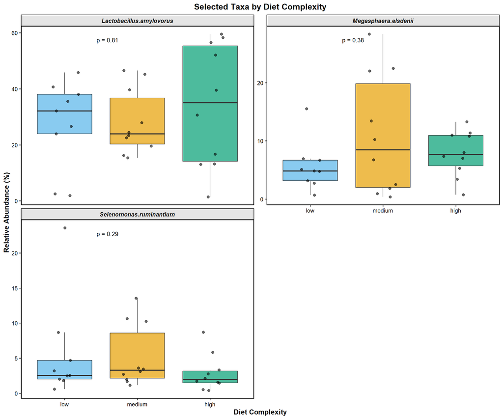

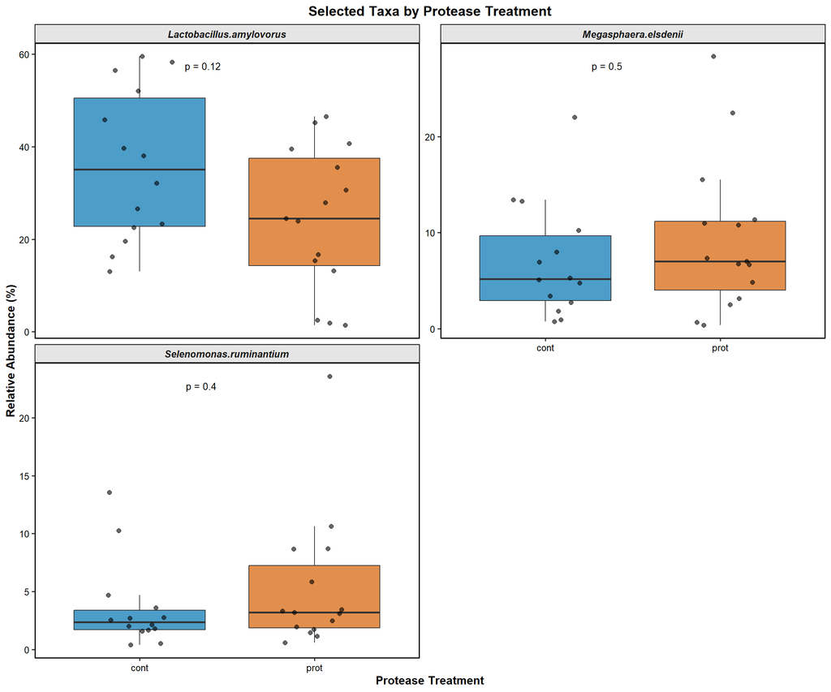

```r
# ============================================
# CHANGE THESE TAXA NAMES AS NEEDED
# ============================================
selected_taxa <- c(
  "Selenomonas ruminantium",
  "Lactobacillus amylovorus",
  "Prevotella copri",
  "Megasphaera elsdenii"
)
# ============================================

# Check which taxa exist in the data
available_taxa <- selected_taxa[selected_taxa %in% rownames(species_frac)]
missing_taxa <- selected_taxa[!selected_taxa %in% rownames(species_frac)]

if (length(missing_taxa) > 0) {
  message("Taxa not found in data: ", paste(missing_taxa, collapse = ", "))
}

if (length(available_taxa) > 0) {

  # Extract data for selected taxa
  plot_data <- data.frame(
    sample = colnames(species_frac),
    t(species_frac[available_taxa, , drop = FALSE])
  )

  # Reshape to long format
  plot_data_long <- plot_data %>%
    pivot_longer(
      cols = -sample,
      names_to = "taxon",
      values_to = "abundance"
    )

  # Merge with metadata
  plot_data_long <- merge(plot_data_long, meta_tab, by.x = "sample", by.y = "row.names")

  # Convert abundance to percentage
  plot_data_long$abundance_pct <- plot_data_long$abundance * 100

  # Plot by Complex
  p1 <- ggplot(plot_data_long, aes(x = complex, y = abundance_pct, fill = complex)) +
    geom_boxplot(outlier.shape = NA, alpha = 0.7) +
    geom_jitter(width = 0.2, size = 2, alpha = 0.6) +
    facet_wrap(~ taxon, scales = "free_y", ncol = 2) +
    scale_fill_manual(values = complex_colors) +
    stat_compare_means(method = "kruskal.test", label = "p.format",
                       label.x = 1.5, label.y.npc = 0.95, size = 3.5) +
    labs(
      x = "Diet Complexity",
      y = "Relative Abundance (%)",
      fill = "Complex",
      title = "Selected Taxa by Diet Complexity"
    ) +
    theme_publication +
    theme(
      legend.position = "none",
      strip.text = element_text(face = "bold.italic", size = 10)
    )

  # Plot by Protease
  p2 <- ggplot(plot_data_long, aes(x = protease, y = abundance_pct, fill = protease)) +
    geom_boxplot(outlier.shape = NA, alpha = 0.7) +
    geom_jitter(width = 0.2, size = 2, alpha = 0.6) +
    facet_wrap(~ taxon, scales = "free_y", ncol = 2) +
    scale_fill_manual(values = protease_colors) +
    stat_compare_means(method = "wilcox.test", label = "p.format",
                       label.x = 1.3, label.y.npc = 0.95, size = 3.5) +
    labs(
      x = "Protease Treatment",
      y = "Relative Abundance (%)",
      fill = "Protease",
      title = "Selected Taxa by Protease Treatment"
    ) +
    theme_publication +
    theme(
      legend.position = "none",
      strip.text = element_text(face = "bold.italic", size = 10)
    )

  print(p1)
  print(p2)

} else {
  print("No selected taxa found in the data")
}
```

#### Plot selected taxa with interaction (Complex × Protease):

Bruno, aqui caso vc queira fazer alguns plots so de alguns taxas. Que vc achar interessante. Ai so mudar o nome e pedir para rodar. Esse codigo é para interacão.

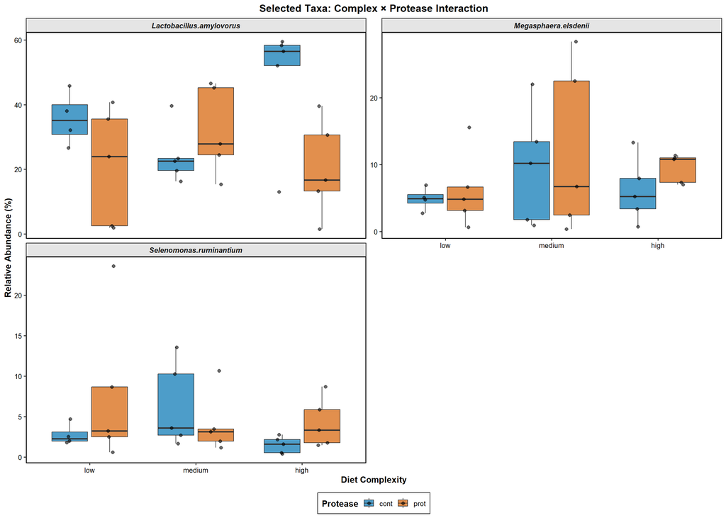

```r
# ============================================
# CHANGE THESE TAXA NAMES AS NEEDED
# ============================================
selected_taxa <- c(
  "Selenomonas ruminantium",
  "Lactobacillus amylovorus",
  "Prevotella copri",
  "Megasphaera elsdenii"
)
# ============================================

# Check which taxa exist in the data
available_taxa <- selected_taxa[selected_taxa %in% rownames(species_frac)]

if (length(available_taxa) > 0) {

  # Extract data for selected taxa
  plot_data <- data.frame(
    sample = colnames(species_frac),
    t(species_frac[available_taxa, , drop = FALSE])
  )

  # Reshape to long format
  plot_data_long <- plot_data %>%
    pivot_longer(
      cols = -sample,
      names_to = "taxon",
      values_to = "abundance"
    )

  # Merge with metadata
  plot_data_long <- merge(plot_data_long, meta_tab, by.x = "sample", by.y = "row.names")

  # Convert abundance to percentage
  plot_data_long$abundance_pct <- plot_data_long$abundance * 100

  # Plot interaction
  p_interaction <- ggplot(plot_data_long, aes(x = complex, y = abundance_pct, fill = protease)) +
    geom_boxplot(outlier.shape = NA, alpha = 0.7) +
    geom_point(position = position_jitterdodge(jitter.width = 0.2), size = 2, alpha = 0.6) +
    facet_wrap(~ taxon, scales = "free_y", ncol = 2) +
    scale_fill_manual(values = protease_colors) +
    labs(
      x = "Diet Complexity",
      y = "Relative Abundance (%)",
      fill = "Protease",
      title = "Selected Taxa: Complex × Protease Interaction"
    ) +
    theme_publication +
    theme(
      legend.position = "bottom",
      strip.text = element_text(face = "bold.italic", size = 10)
    )

  print(p_interaction)

} else {
  print("No selected taxa found in the data")
}
```

#### Single taxon detailed plot:

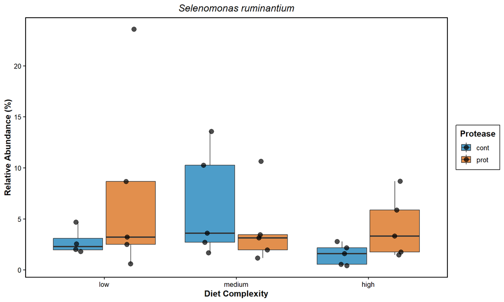

```r
# ============================================
# CHANGE THIS TAXON NAME AS NEEDED
# ============================================
single_taxon <- "Selenomonas ruminantium"
# ============================================

if (single_taxon %in% rownames(species_frac)) {

  # Extract data
  taxon_data <- data.frame(
    sample = colnames(species_frac),
    abundance = as.numeric(species_frac[single_taxon, ])
  )

  # Merge with metadata
  taxon_data <- merge(taxon_data, meta_tab, by.x = "sample", by.y = "row.names")
  taxon_data$abundance_pct <- taxon_data$abundance * 100

  # Pairwise comparisons for complex
  comparisons_complex <- list(c("low", "medium"), c("low", "high"), c("medium", "high"))

  # Plot
  p_single <- ggplot(taxon_data, aes(x = complex, y = abundance_pct, fill = protease)) +
    geom_boxplot(outlier.shape = NA, alpha = 0.7, position = position_dodge(0.8)) +
    geom_point(position = position_jitterdodge(jitter.width = 0.2, dodge.width = 0.8),
               size = 3, alpha = 0.7) +
    scale_fill_manual(values = protease_colors) +
    labs(
      x = "Diet Complexity",
      y = "Relative Abundance (%)",
      fill = "Protease",
      title = bquote(italic(.(single_taxon)))
    ) +
    theme_publication +
    theme(
      legend.position = "right",
      plot.title = element_text(face = "bold.italic", size = 14)
    )

  print(p_single)

} else {
  print(paste("Taxon not found:", single_taxon))
}
```

#### **Plot using CLR-transformed data (for statistical comparisons):**

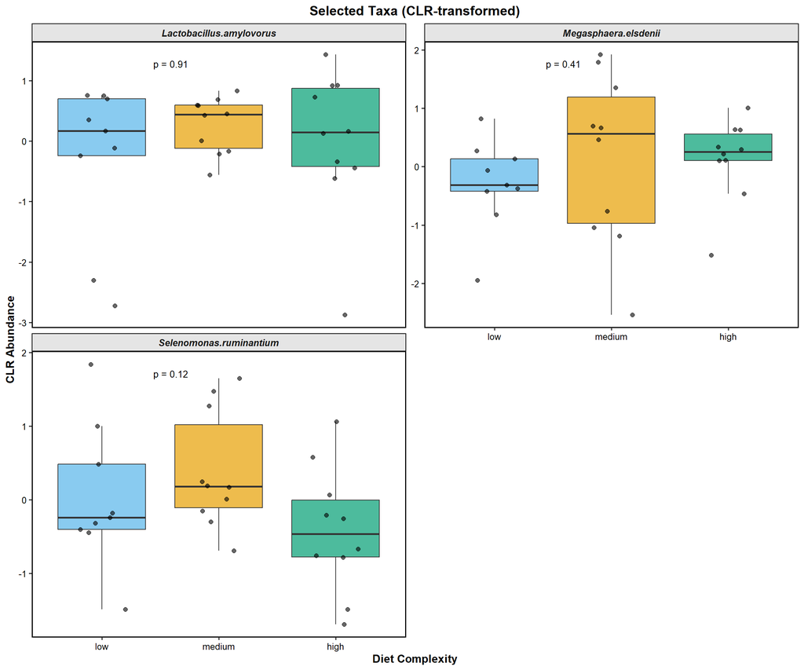

```r
# ============================================
# CHANGE THESE TAXA NAMES AS NEEDED
# ============================================
selected_taxa <- c(
  "Selenomonas ruminantium",
  "Lactobacillus amylovorus",
  "Prevotella copri",
  "Megasphaera elsdenii"
)
# ============================================

# Check which taxa exist in the data
available_taxa <- selected_taxa[selected_taxa %in% rownames(species_counts_filtered)]

if (length(available_taxa) > 0) {

  # CLR transform
  species_pseudo <- species_counts_filtered + 1
  species_clr <- log(species_pseudo) - rowMeans(log(species_pseudo))

  # Extract data for selected taxa
  plot_data <- data.frame(
    sample = colnames(species_clr),
    t(species_clr[available_taxa, , drop = FALSE])
  )

  # Reshape to long format
  plot_data_long <- plot_data %>%
    pivot_longer(
      cols = -sample,
      names_to = "taxon",
      values_to = "clr_abundance"
    )

  # Merge with metadata
  plot_data_long <- merge(plot_data_long, meta_tab, by.x = "sample", by.y = "row.names")

  # Plot by Complex
  p_clr <- ggplot(plot_data_long, aes(x = complex, y = clr_abundance, fill = complex)) +
    geom_boxplot(outlier.shape = NA, alpha = 0.7) +
    geom_jitter(width = 0.2, size = 2, alpha = 0.6) +
    facet_wrap(~ taxon, scales = "free_y", ncol = 2) +
    scale_fill_manual(values = complex_colors) +
    stat_compare_means(method = "kruskal.test", label = "p.format",
                       label.x = 1.5, label.y.npc = 0.95, size = 3.5) +
    labs(
      x = "Diet Complexity",
      y = "CLR Abundance",
      fill = "Complex",
      title = "Selected Taxa (CLR-transformed)"
    ) +
    theme_publication +
    theme(
      legend.position = "none",
      strip.text = element_text(face = "bold.italic", size = 10)
    )

  print(p_clr)

} else {
  print("No selected taxa found in the data")
}
```

## Taxonomic Barplots - All Levels

### **Top taxa barplot - Phylum level:**

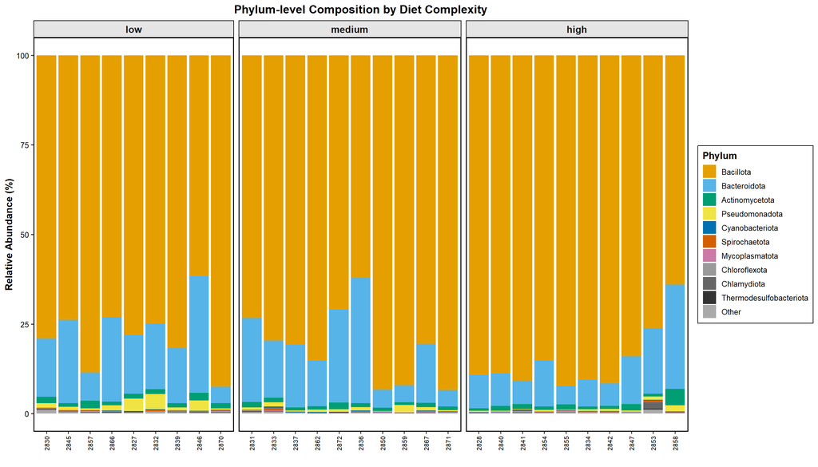

```r
# ============================================
# SETTINGS
# ============================================
n_top_taxa <- 10  # Number of top taxa to show
# ============================================

# Calculate mean abundance per taxon
phylum_mean <- rowMeans(phylum_frac)

# Get top taxa
top_phyla <- names(sort(phylum_mean, decreasing = TRUE))[1:n_top_taxa]

# Prepare data
phylum_plot <- as.data.frame(t(phylum_frac))
phylum_plot$sample <- rownames(phylum_plot)

# Merge with metadata
phylum_plot <- merge(phylum_plot, meta_tab, by.x = "sample", by.y = "row.names")

# Reshape to long format
phylum_long <- phylum_plot %>%
  pivot_longer(
    cols = all_of(rownames(phylum_frac)),
    names_to = "phylum",
    values_to = "abundance"
  )

# Group low-abundance taxa as "Other"
phylum_long$phylum_grouped <- ifelse(phylum_long$phylum %in% top_phyla,
                                      phylum_long$phylum, "Other")

# Aggregate
phylum_agg <- phylum_long %>%
  group_by(sample, complex, protease, phylum_grouped) %>%
  summarise(abundance = sum(abundance), .groups = "drop")

# Set factor order (top taxa + Other at end)
phylum_agg$phylum_grouped <- factor(phylum_agg$phylum_grouped,
                                     levels = c(top_phyla, "Other"))

# Order samples by complex and protease
phylum_agg$sample <- factor(phylum_agg$sample,
                             levels = rownames(meta_tab)[order(meta_tab$complex, meta_tab$protease)])

# Extended color palette for taxa
taxa_colors <- c(cb_palette, "#666666", "#333333", "#AAAAAA")

# Plot
ggplot(phylum_agg, aes(x = sample, y = abundance * 100, fill = phylum_grouped)) +
  geom_bar(stat = "identity", position = "stack") +
  scale_fill_manual(values = taxa_colors) +
  facet_grid(~ complex, scales = "free_x", space = "free_x") +
  labs(
    x = "",
    y = "Relative Abundance (%)",
    fill = "Phylum",
    title = "Phylum-level Composition by Diet Complexity"
  ) +
  theme_publication +
  theme(
    axis.text.x = element_text(angle = 90, hjust = 1, vjust = 0.5, size = 8),
    legend.position = "right",
    strip.text = element_text(face = "bold", size = 12)
  )
```

### Top taxa barplot - Genus level:

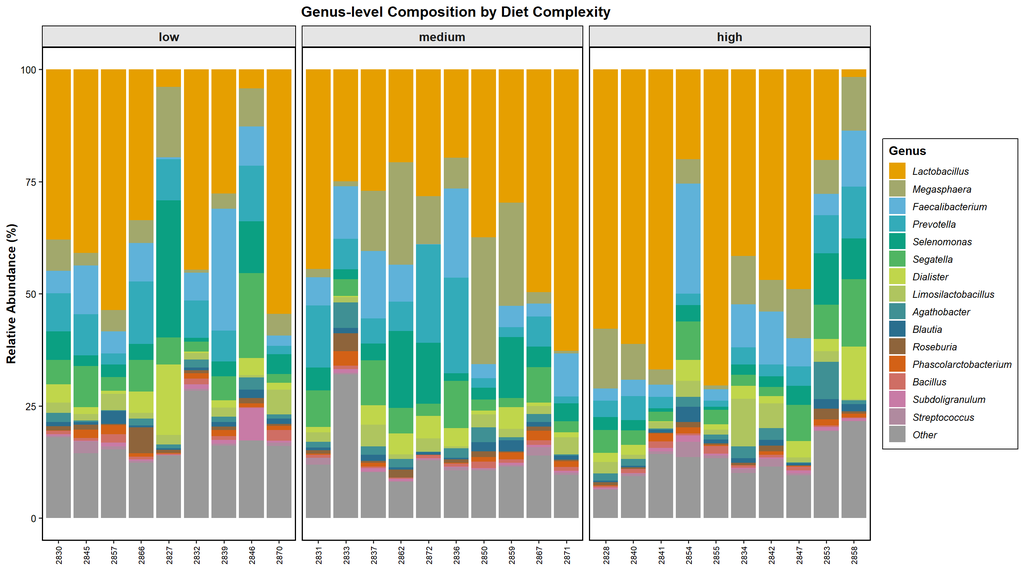

```r
# ============================================
# SETTINGS
# ============================================
n_top_taxa <- 15  # Number of top taxa to show
# ============================================

# Calculate mean abundance per taxon
genus_mean <- rowMeans(genus_frac)

# Get top taxa
top_genera <- names(sort(genus_mean, decreasing = TRUE))[1:n_top_taxa]

# Prepare data
genus_plot <- as.data.frame(t(genus_frac))
genus_plot$sample <- rownames(genus_plot)

# Merge with metadata
genus_plot <- merge(genus_plot, meta_tab, by.x = "sample", by.y = "row.names")

# Reshape to long format
genus_long <- genus_plot %>%
  pivot_longer(
    cols = all_of(rownames(genus_frac)),
    names_to = "genus",
    values_to = "abundance"
  )

# Group low-abundance taxa as "Other"
genus_long$genus_grouped <- ifelse(genus_long$genus %in% top_genera,
                                    genus_long$genus, "Other")

# Aggregate
genus_agg <- genus_long %>%
  group_by(sample, complex, protease, genus_grouped) %>%
  summarise(abundance = sum(abundance), .groups = "drop")

# Set factor order
genus_agg$genus_grouped <- factor(genus_agg$genus_grouped,
                                   levels = c(top_genera, "Other"))

# Order samples
genus_agg$sample <- factor(genus_agg$sample,
                            levels = rownames(meta_tab)[order(meta_tab$complex, meta_tab$protease)])

# Extended color palette
taxa_colors_ext <- colorRampPalette(cb_palette)(n_top_taxa + 1)

# Plot
ggplot(genus_agg, aes(x = sample, y = abundance * 100, fill = genus_grouped)) +
  geom_bar(stat = "identity", position = "stack") +
  scale_fill_manual(values = taxa_colors_ext) +
  facet_grid(~ complex, scales = "free_x", space = "free_x") +
  labs(
    x = "",
    y = "Relative Abundance (%)",
    fill = "Genus",
    title = "Genus-level Composition by Diet Complexity"
  ) +
  theme_publication +
  theme(
    axis.text.x = element_text(angle = 90, hjust = 1, vjust = 0.5, size = 8),
    legend.position = "right",
    legend.text = element_text(face = "italic"),
    strip.text = element_text(face = "bold", size = 12)
  )
```

### Top taxa barplot - Species level:

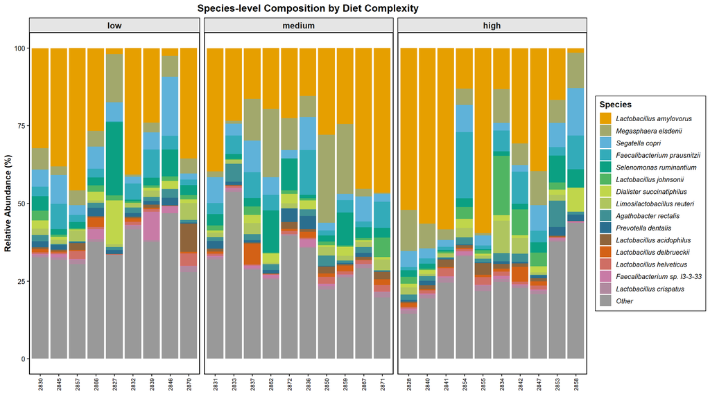

```r
# ============================================
# SETTINGS
# ============================================
n_top_taxa <- 15  # Number of top taxa to show
# ============================================

# Calculate mean abundance per taxon
species_mean <- rowMeans(species_frac)

# Get top taxa
top_species <- names(sort(species_mean, decreasing = TRUE))[1:n_top_taxa]

# Prepare data
species_plot <- as.data.frame(t(species_frac))
species_plot$sample <- rownames(species_plot)

# Merge with metadata
species_plot <- merge(species_plot, meta_tab, by.x = "sample", by.y = "row.names")

# Reshape to long format
species_long <- species_plot %>%
  pivot_longer(
    cols = all_of(rownames(species_frac)),
    names_to = "species",
    values_to = "abundance"
  )

# Group low-abundance taxa as "Other"
species_long$species_grouped <- ifelse(species_long$species %in% top_species,
                                        species_long$species, "Other")

# Aggregate
species_agg <- species_long %>%
  group_by(sample, complex, protease, species_grouped) %>%
  summarise(abundance = sum(abundance), .groups = "drop")

# Set factor order
species_agg$species_grouped <- factor(species_agg$species_grouped,
                                       levels = c(top_species, "Other"))

# Order samples
species_agg$sample <- factor(species_agg$sample,
                              levels = rownames(meta_tab)[order(meta_tab$complex, meta_tab$protease)])

# Extended color palette
taxa_colors_ext <- colorRampPalette(cb_palette)(n_top_taxa + 1)

# Plot
ggplot(species_agg, aes(x = sample, y = abundance * 100, fill = species_grouped)) +
  geom_bar(stat = "identity", position = "stack") +
  scale_fill_manual(values = taxa_colors_ext) +
  facet_grid(~ complex, scales = "free_x", space = "free_x") +
  labs(
    x = "",
    y = "Relative Abundance (%)",
    fill = "Species",
    title = "Species-level Composition by Diet Complexity"
  ) +
  theme_publication +
  theme(
    axis.text.x = element_text(angle = 90, hjust = 1, vjust = 0.5, size = 8),
    legend.position = "right",
    legend.text = element_text(face = "italic"),
    strip.text = element_text(face = "bold", size = 12)
  )
```

```r
capabilities()
```

```
       jpeg         png        tiff       tcltk         X11        aqua
       TRUE        TRUE        TRUE        TRUE       FALSE       FALSE
   http/ftp     sockets      libxml        fifo      cledit       iconv
       TRUE        TRUE       FALSE        TRUE       FALSE        TRUE
        NLS       Rprof     profmem       cairo         ICU long.double
       TRUE        TRUE        TRUE        TRUE        TRUE        TRUE
    libcurl
       TRUE
```